# 2021 Q

Jake Cavaiani

12/9/2021

### 2021

Vault, French, and Moose only have data from 6/29 on due to data not being uploaded to the drive before the computer had water damage and lost the data….reminder to ALWAYS BACK UP DATA. We can try and run a model to apply data from Poker to extrapolate missing water level points at other sites.

2021 data comes from DoD Project-> 2021 AK sensors -> Discharge->PT->‘site’

2021 data was taken using a Wading rod and salt slug dilution and an ADCP at Stuart and Moose one time during the season.

### comparing PTs

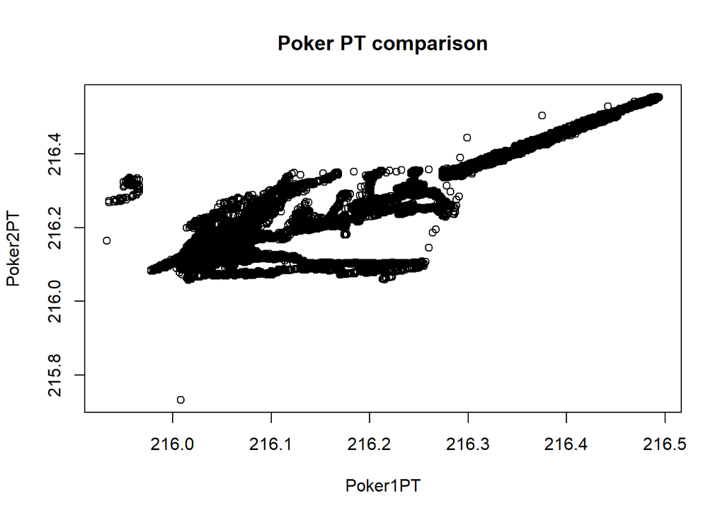

### STRT Comp

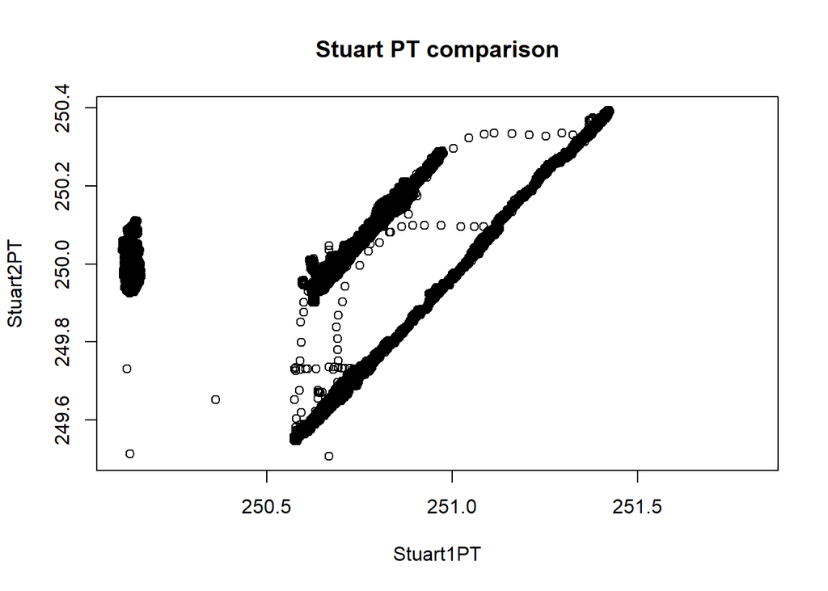

### FRCH COMP

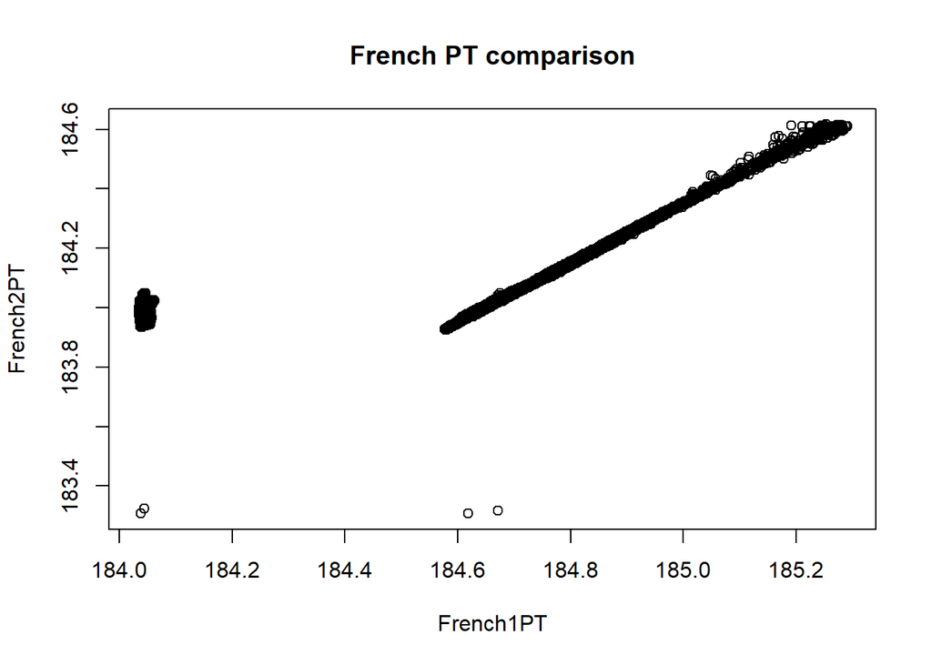

### MOOS comp

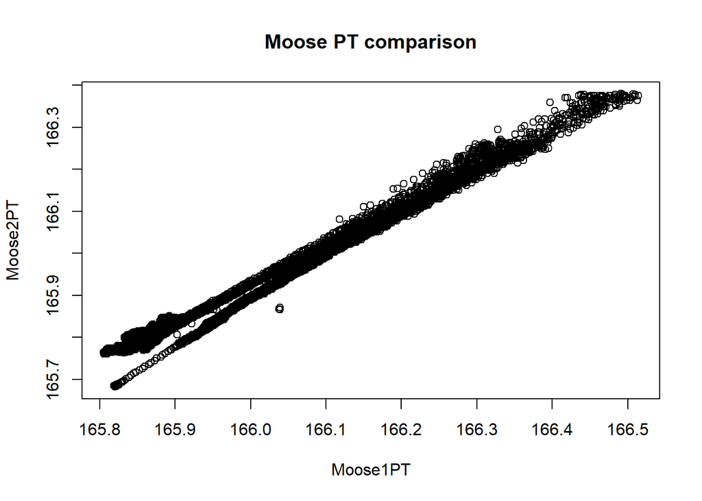

# Moose

### Raw Moose PT1

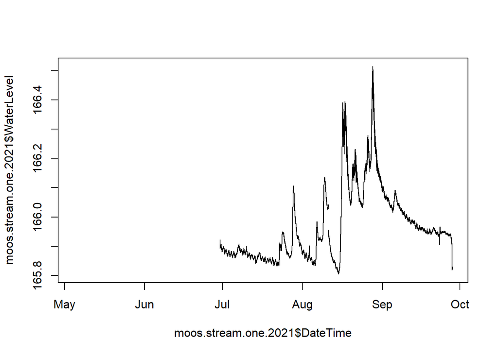

Need to clean out of water points at the end of the dataframe…let the cleaning commence!

### Moose PT1 2.0

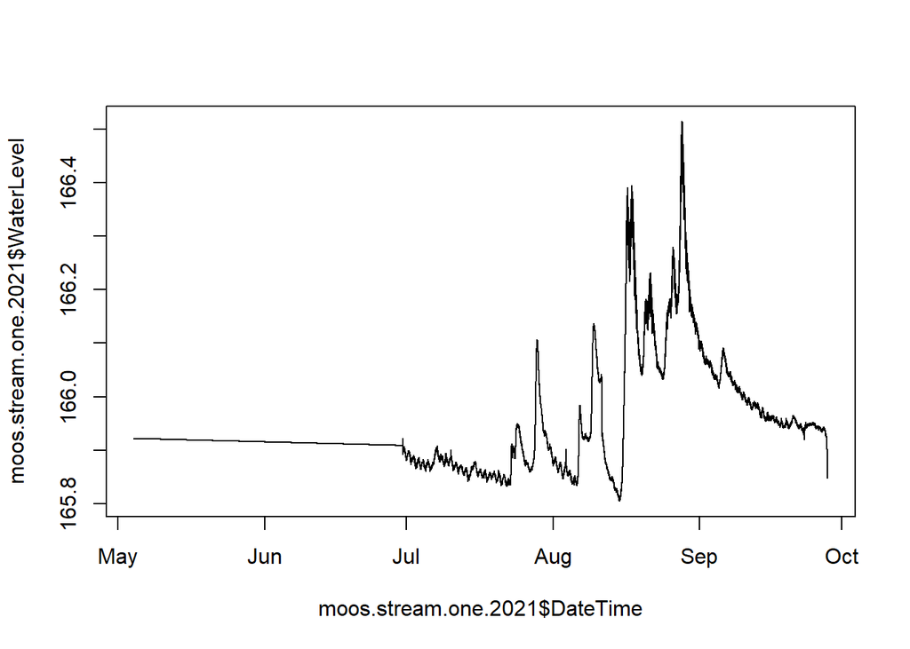

1) removed out of water points during decommission on 9/28/21 2) removed vertical errant points in middle of September

### Raw Moose PT2

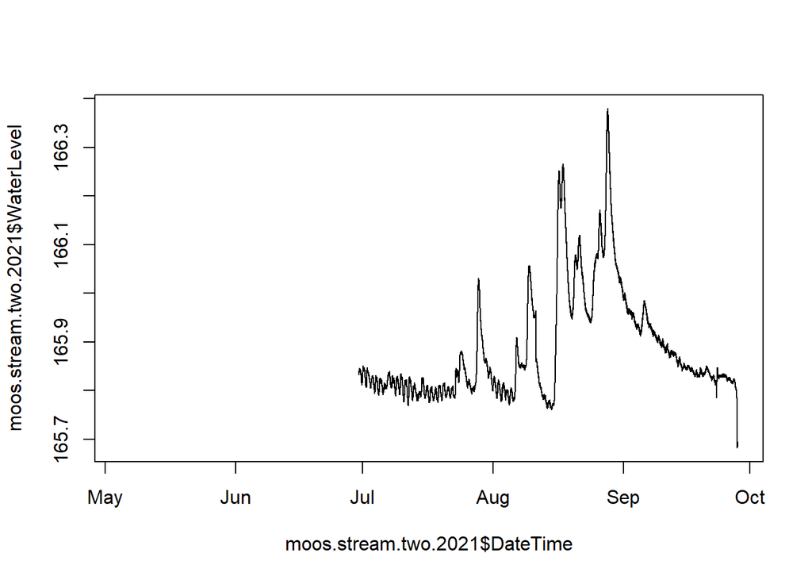

Need to remove out of water points associated with decommission…let the cleaning commence!

### Moose PT2 2.0

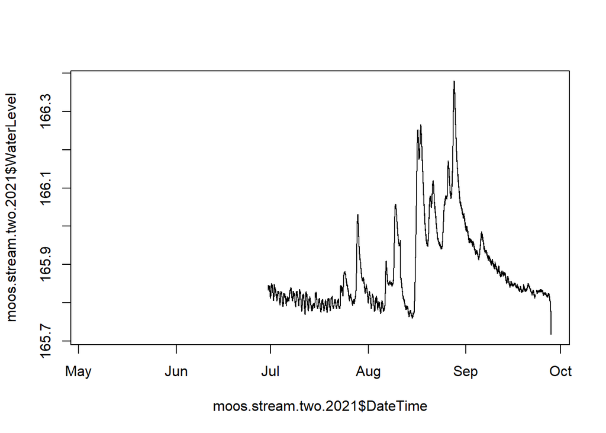

## Export PT data to csv in DoD_Discharge->PT_data->2021

## Raw rating curve for MOOS PT1

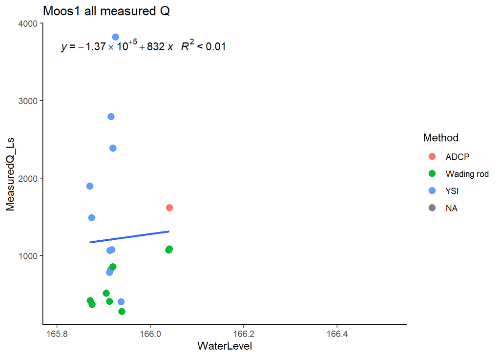

High YSI pints will have to be removed

### MOOS PT1 2.0

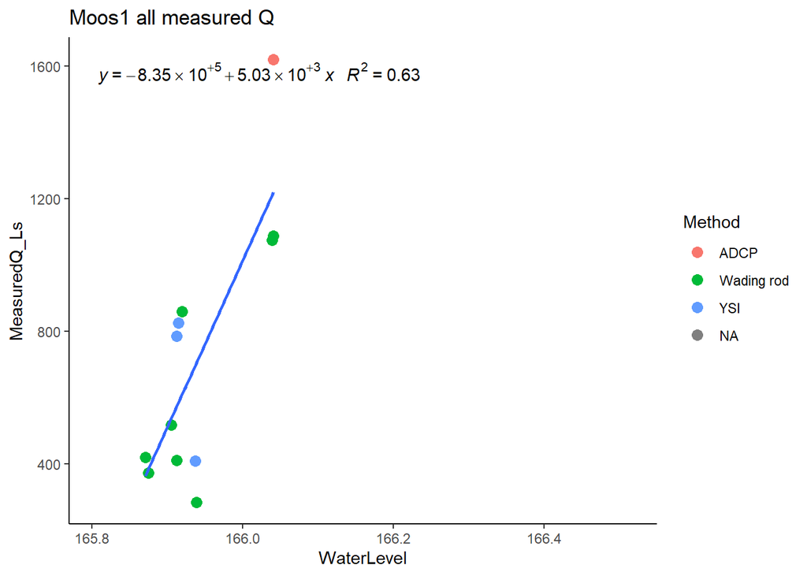

1) removed YSI points above 1000 Ls

## Raw rating curve for MOOS PT2

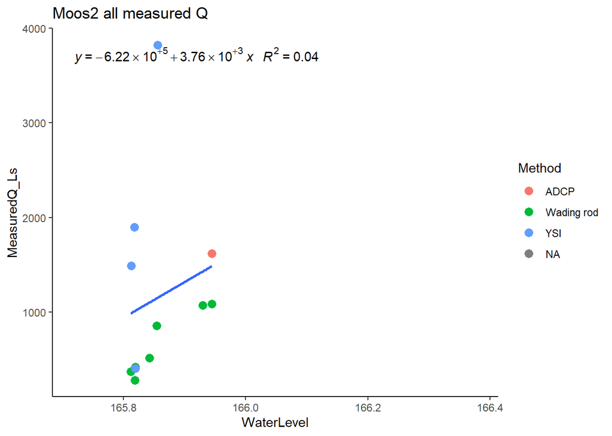

Need to remove YSI’s

### MOOS PT2

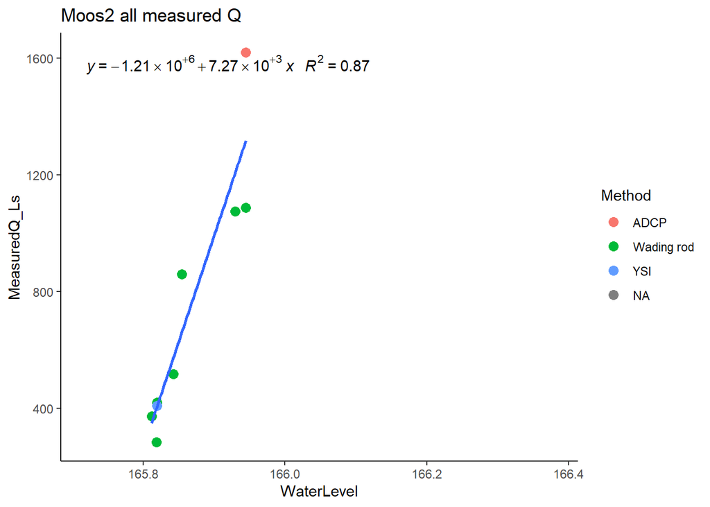

1) removed YSI points above 1000 Ls

### Predicted Q MOOS PT1

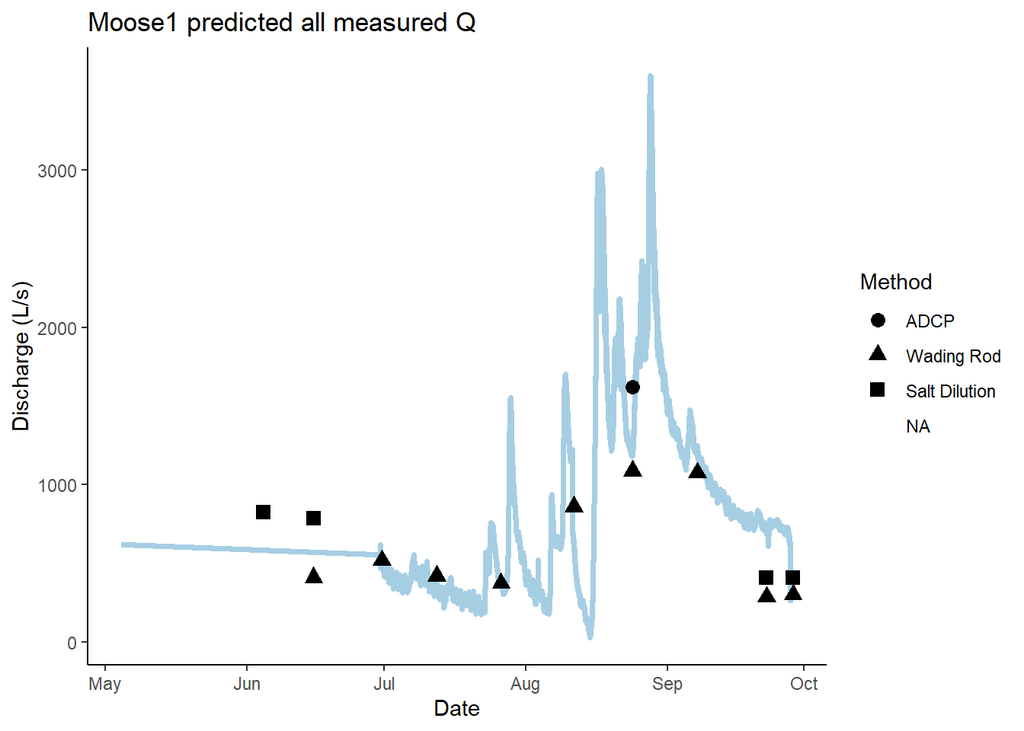

Not too shabby

### Predicted Q MOOS PT2

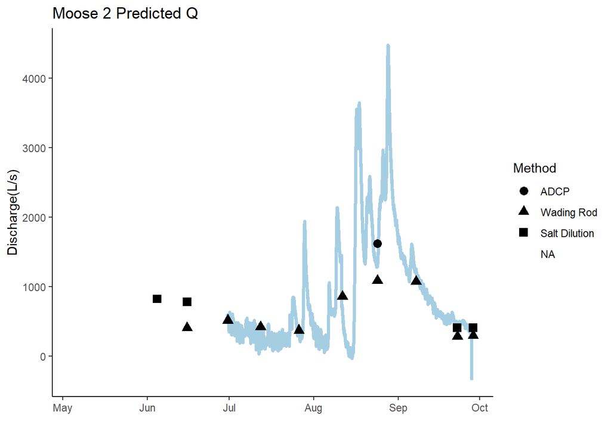

Nott too shabby

### Average predicted Q MOOS

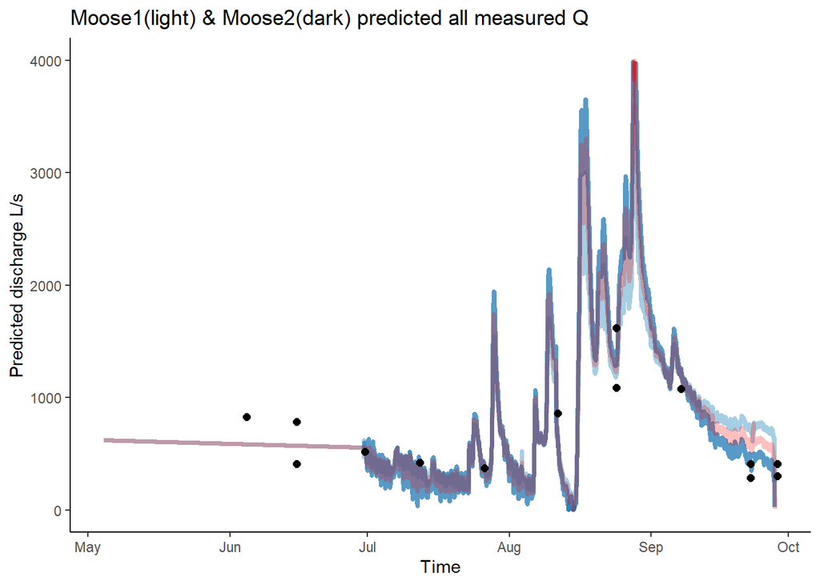

Looks good and red should be exported as a csv

## Export PT data to csv in DoD_Discharge->Predicted_discharge->2021

# French

### Raw French PT1

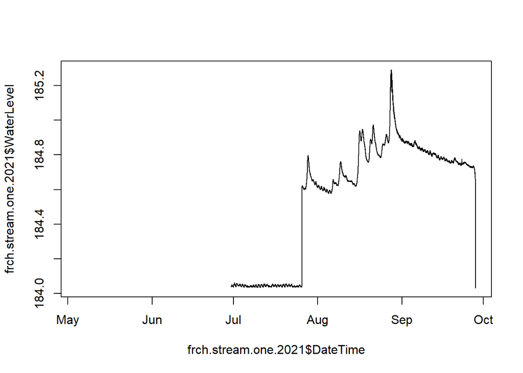

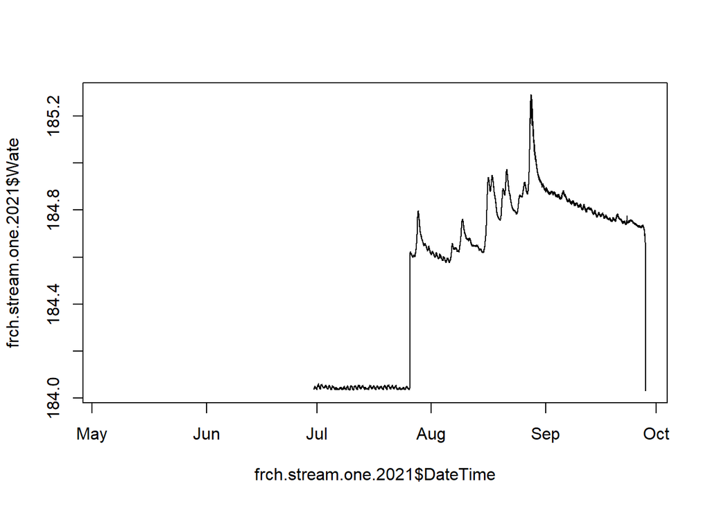

It appears that I need to shift the July data up to what it looks like to the end of July and take the out of water points associated with decommission out of data frame

### French PT1 2.0

```
## [1] 0.568
```

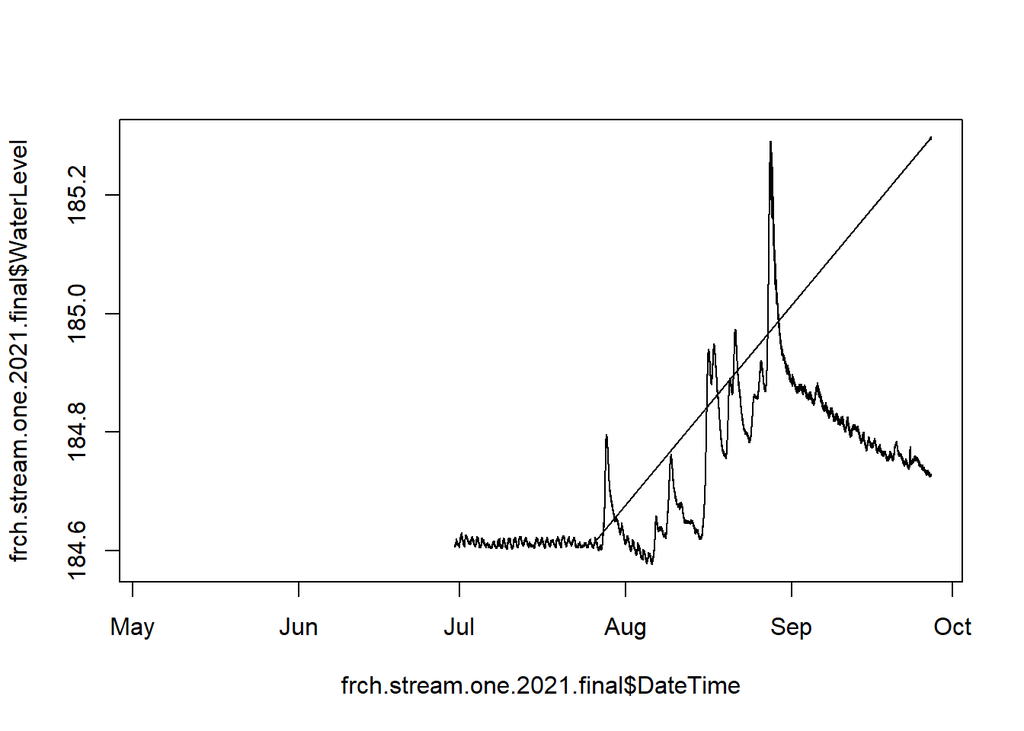

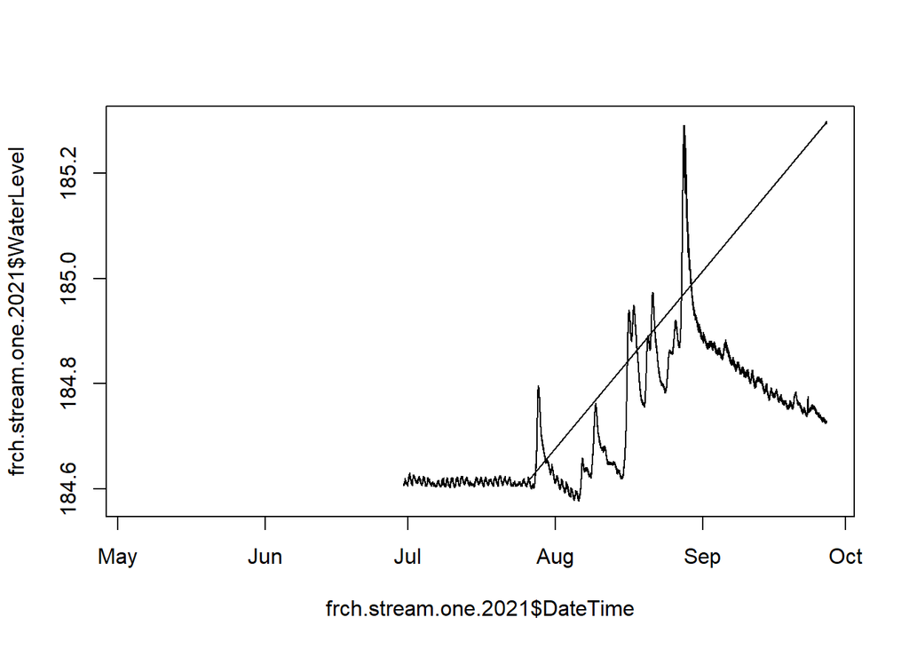

1) removed out of water points associated with decommission 2) shifted July data up to the rest of the data set due with cleaning

### Raw French PT2

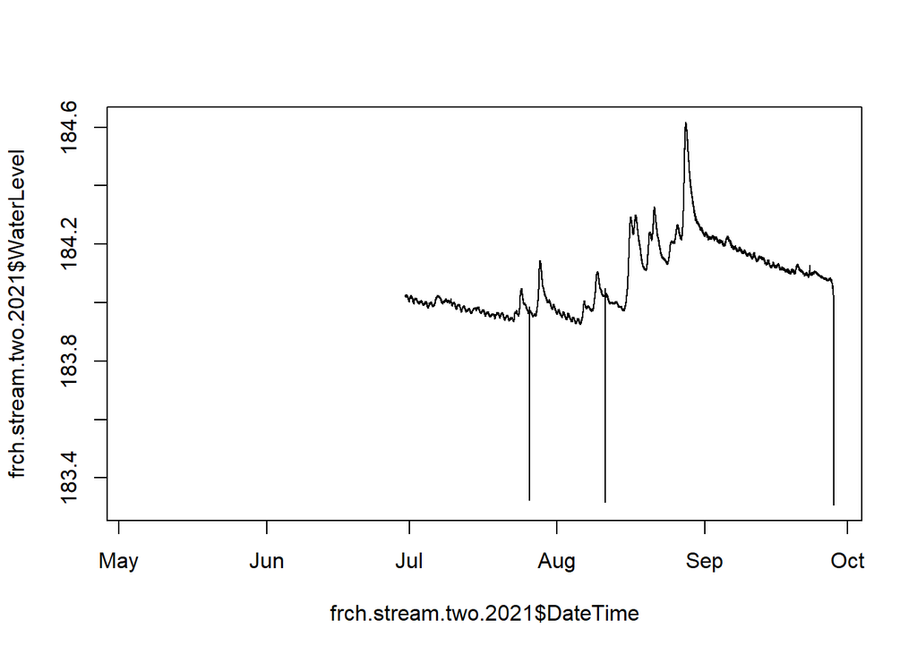

### French PT2 2.0

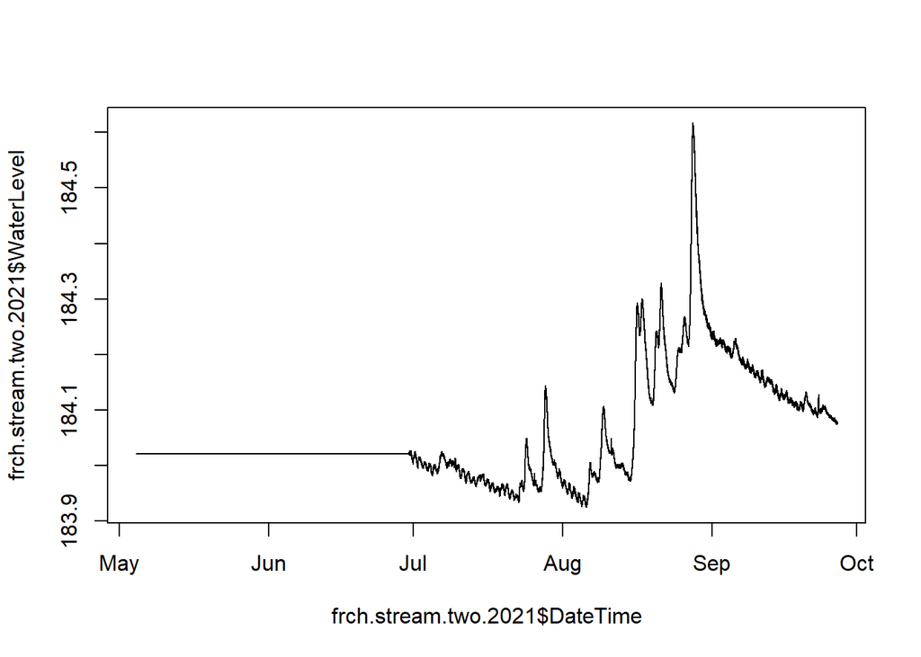

Not too shabby

## Export PT data to csv in DoD_Discharge->PT_data->2021

### Raw Rating curveFrench PT1

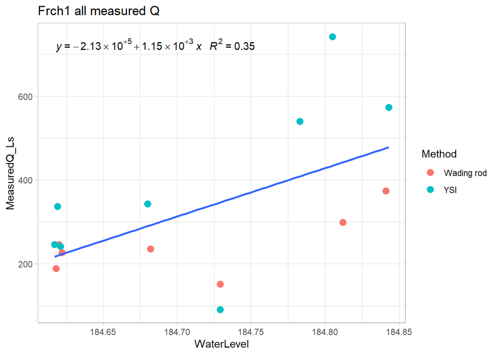

Lets try averaging measurements by date and remove that medium water level, low measured Q point.

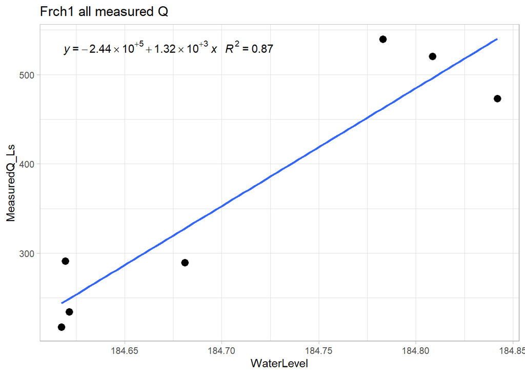

```r
Frch1comb.2021.1 <- Frch1comb.2021 %>% filter(MeasuredQ_Ls > 180) %>% group_by(Date) %>% summarise(MeasuredQ_Ls = mean(MeasuredQ_Ls, na.rm = TRUE),
                                                                    WaterLevel = mean(WaterLevel, na.rm = TRUE),
                                                                    DateTime = min(DateTime, na.rm = TRUE))
FRCH1.lm.2021 <- lm(Frch1comb.2021.1$MeasuredQ_Ls ~ Frch1comb.2021.1$WaterLevel)

ggplot(aes(x = WaterLevel, y = MeasuredQ_Ls), data = Frch1comb.2021.1) +
  geom_point( size = 3) +
  geom_smooth(method = "lm", se=FALSE, formula = frch.formula) +
  stat_poly_eq(formula = frch.formula,
               aes(label = paste(..eq.label.., ..rr.label.., sep = "~~~")),
               parse = TRUE) +
  theme_light() +
  ggtitle("Frch1 all measured Q")
```

### Raw Rating curve French PT2

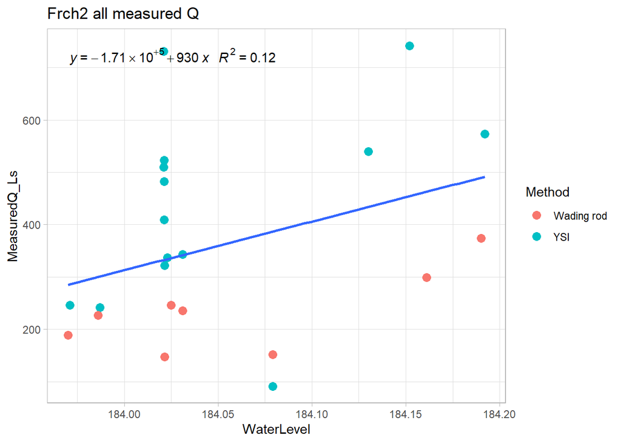

Lets try averaging measurements by date and remove that medium water level, low measured Q point and the 4 mid water level, high Q points.

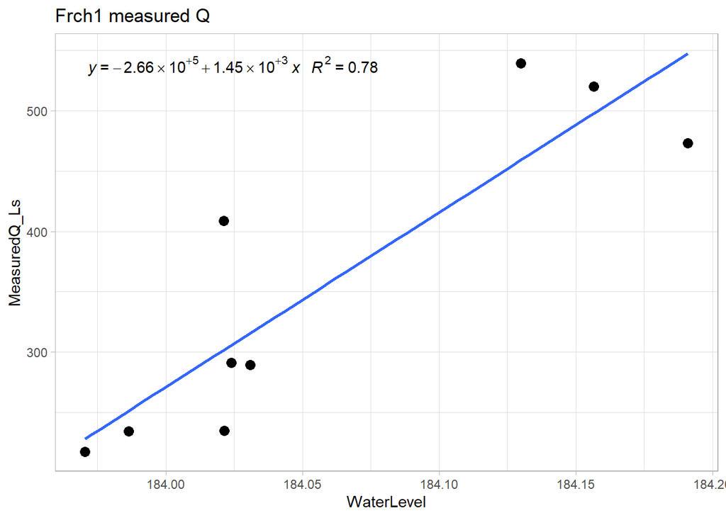

```r
Frch2comb.2021.2 <- Frch2comb.2021 %>% filter(Date != "2021-09-28", MeasuredQ_Ls < 450 | WaterLevel > 184.05) %>% group_by(Date) %>% summarise(MeasuredQ_Ls = mean(MeasuredQ_Ls, na.rm = TRUE),
                                                                   WaterLevel = mean(WaterLevel, na.rm = TRUE),
                                                                   DateTime = min(DateTime, na.rm = TRUE))
FRCH2.lm.2021 <- lm(Frch2comb.2021.2$MeasuredQ_Ls ~ Frch2comb.2021.2$WaterLevel)

frch.formula = y ~ x

ggplot(aes(x = WaterLevel, y = MeasuredQ_Ls), data = Frch2comb.2021.2) +
  geom_point( size = 3) +
  geom_smooth(method = "lm", se=FALSE, formula = frch.formula) +
  stat_poly_eq(formula = frch.formula,
               aes(label = paste(..eq.label.., ..rr.label.., sep = "~~~")),
               parse = TRUE) +
  theme_light() +
  ggtitle("Frch1 measured Q")
```

### Predicted Q FRCH PT1

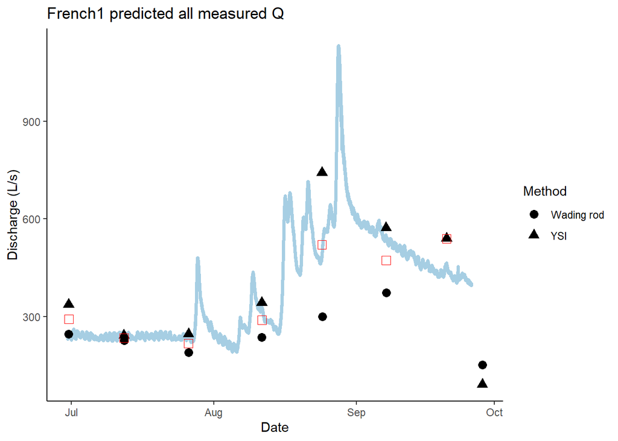

Red points are the averaged points used in the rating curve.

### Predicted Q FRCH PT2

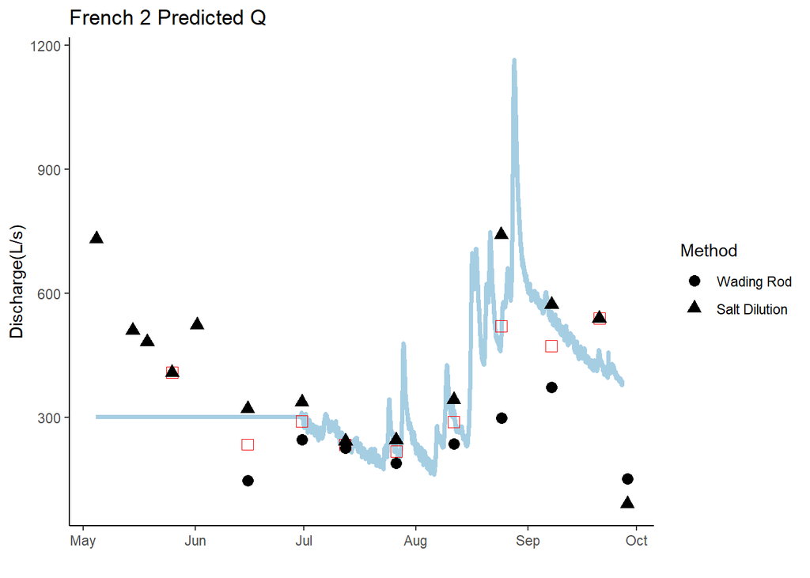

Not too shabby

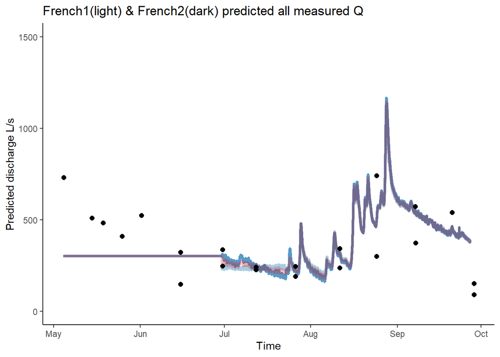

Red should be exported as a csv

## Export PT data to csv in DoD_Discharge->Predicted_discharge->2021

### Raw Poker PT1

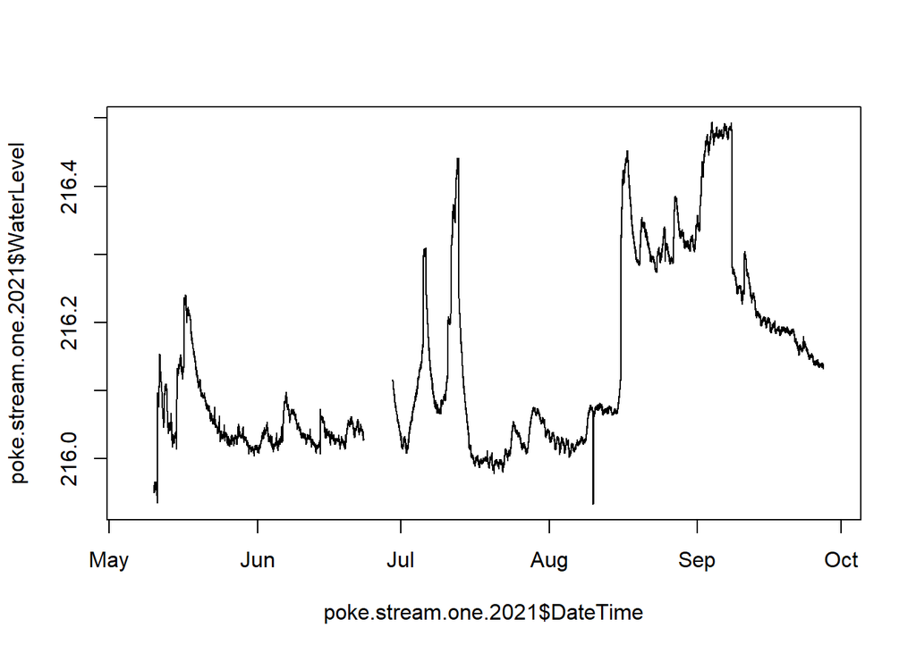

2 beaver dams in July and one in the beginning of september….let the cleaning commence!

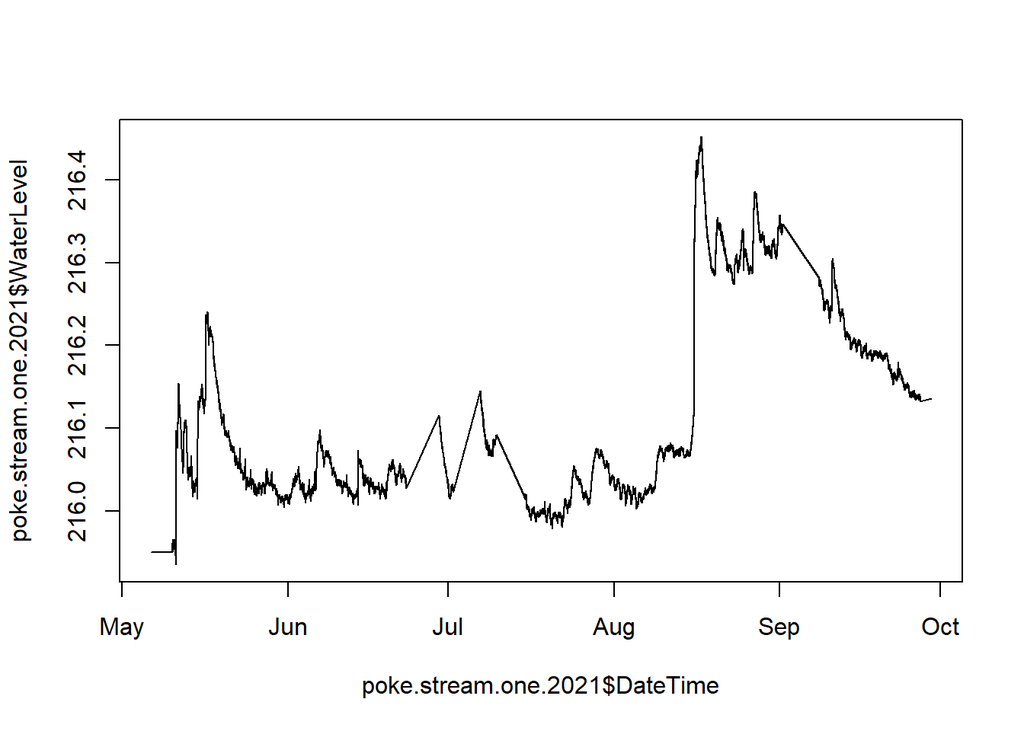

1) Removed beaver dam raise in water level in the beginning, middle of July and beginning of September 2) check the middle of August

### Raw Poker PT2

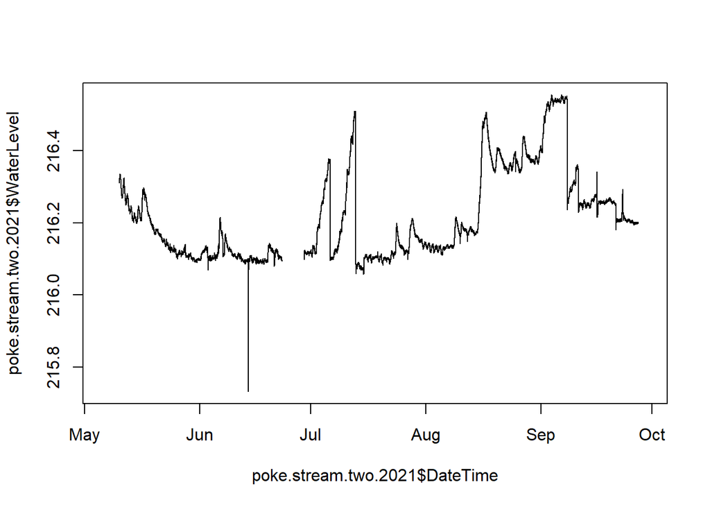

Out of water point in June, beaver dams….let the cleaning commence!